# Task 08 World Data Investigations - Part 2

Rachael Smith

June 04, 2020

## Background

Child Mortality and Life Expectancy by country data from: https://ourworldindata.org/financing-healthcare/

I created these maps by referencing this site: https://www.datanovia.com/en/blog/how-to-create-a-map-using-ggplot2/

```r
serbia_dat <- ourworldindata::financing_healthcare %>%
  filter(country == "Greenland")

africa_dat <- ourworldindata::financing_healthcare %>%
  group_by(country) %>%
  filter(continent == "Africa") %>%
  select(country, child_mort)

america_dat <- ourworldindata::financing_healthcare %>%
  group_by(country) %>%
  filter(continent == "Americas") %>%
  select(country, child_mort)

fin_dat <- ourworldindata::financing_healthcare %>%
  filter(year == "1900" | year == "1960" | year == "2000" | year == "2010") %>%
  mutate(country = replace(country, country == "Democratic Republic of Congo", "Democratic Republic of the Congo")) %>%
  mutate(country = replace(country, country == "United States", "USA")) %>%
  mutate(country = replace(country, country == "Congo", "Republic of Congo")) %>%
   mutate(country = replace(country, country == "Cote d'Ivoire", "Ivory Coast")) %>%
  rename("region" = country, "lifeExp" = life_expectancy) %>%
  select(year, region, lifeExp, child_mort)
```

```r
# Upload world map data

world_map <- map_data("world") %>%
  mutate(region = replace(region, region == "Antigua", "Antigua and Barbuda")) %>%
  mutate(region = replace(region, region == "Barbuda", "Antigua and Barbuda"))

#join the two datasets by region

fin_dat.map <- left_join(fin_dat, world_map, by = "region")
```

## Graphs

#### Comparison of 100 Year Child Mortality Rate

How has the childhood mortality rate decreased over the past 100 years?

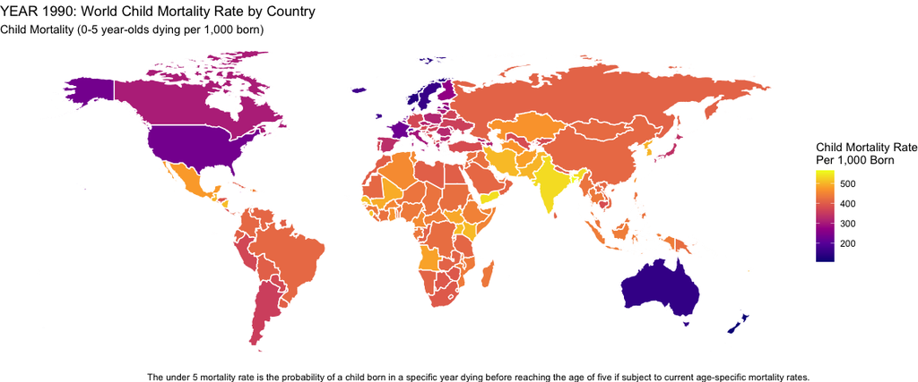

```r
# child mortality rate in the year 1900

mort_1900 <-  fin_dat.map %>%
  filter(year == "1900")

ggplot(data = mort_1900, aes(map_id = region, fill = child_mort)) +
  geom_map(map = mort_1900, color = "white") +
  expand_limits(x = mort_1900$long, y = mort_1900$lat) +
  scale_fill_viridis_c(option = "C") +
  labs(title = "YEAR 1990: World Child Mortality Rate by Country", subtitle= "Child Mortality (0-5 year-olds dying per 1,000 born)", fill = "Child Mortality Rate\nPer 1,000 Born", x = "Year 1900", caption = "The under 5 mortality rate is the probability of a child born in a specific year dying before reaching the age of five if subject to current age-specific mortality rates.")
```

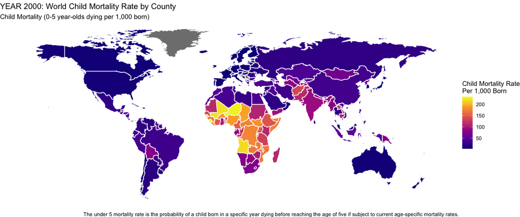

```r
#child mortality rate in the year 2000

mort_2000 <-  fin_dat.map %>%
  filter(year == "2000")

ggplot(data = mort_2000, aes(map_id = region, fill = child_mort)) +
  geom_map(map = mort_2000, color = "white") +
  expand_limits(x = mort_2000$long, y = mort_2000$lat) +
  scale_fill_viridis_c(option = "C") +
  labs(title = "YEAR 2000: World Child Mortality Rate by County", subtitle= "Child Mortality (0-5 year-olds dying per 1,000 born)", fill = "Child Mortality Rate\nPer 1,000 Born", x = "Year: 2000", caption = "The under 5 mortality rate is the probability of a child born in a specific year dying before reaching the age of five if subject to current age-specific mortality rates.")
```

#### Comparison of 50 Year Life Expectancy

How has the life expectancy for adults changed over the past 50 years?

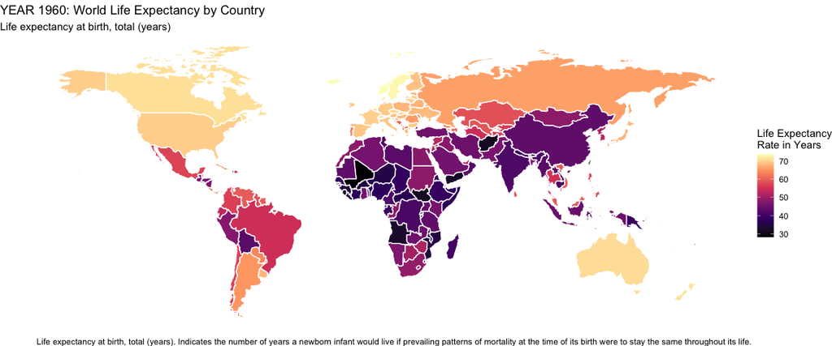

```r
#Life Expectancy in 1960
plot_1960 <-  fin_dat.map %>%
  filter(year == "1960")

ggplot(data = plot_1960, aes(map_id = region, fill = lifeExp)) +
  geom_map(map = plot_1960, color = "white") +
  expand_limits(x = plot_1960$long, y = plot_1960$lat) +
  scale_fill_viridis_c(option = "A") +
  labs(title = "YEAR 1960: World Life Expectancy by Country", subtitle = "Life expectancy at birth, total (years)", fill = "Life Expectancy\nRate in Years", x = "Year: 1960", caption = "Life expectancy at birth, total (years). Indicates the number of years a newborn infant would live if prevailing patterns of mortality at the time of its birth were to stay the same throughout its life.")
```

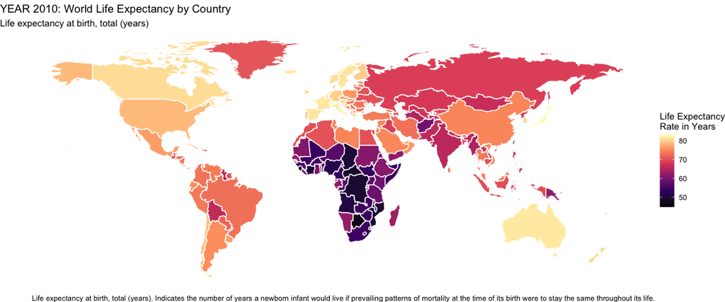

```r
# Use this R-Chunk to plot & visualize your data!
plot_2010 <-  fin_dat.map %>%
  filter(year == "2010")

ggplot(data = plot_2010, aes(map_id = region, fill = lifeExp)) +
  geom_map(map = plot_2010, color = "white") +
  expand_limits(x = plot_2010$long, y = plot_2010$lat) +
  scale_fill_viridis_c(option = "A") +
  labs(title = "YEAR 2010: World Life Expectancy by Country", subtitle = "Life expectancy at birth, total (years)", fill = "Life Expectancy\nRate in Years", x = "Year:1990",caption ="Life expectancy at birth, total (years). Indicates the number of years a newborn infant would live if prevailing patterns of mortality at the time of its birth were to stay the same throughout its life.")
```

## Conclusions

There have been considerable changes in infant mortality rates over the past 100 years. There have also been considerable increased life expectancy over the past 50 years.

This was my biggest challenge yet. I spent many hours trying to get this to work, without knowing if I would ever get it to work. There was so much data collected, I had to look through and determine which years had enough data to make it worth it.

When I finally got the map loaded, it felt like magic! But a lot of countries were missing, including the US, a few African countries, Greenland, etc. I had to look at maps of the various countries to see if I could figure out which country it was, and why it was missing. In many cases, countries were missing because there wasn’t data. I spent quite a bit of time testing my map with different years to see how many countries I had data for.  
In some cases, it was also because the two datasets used different names for the countries. For example, the financial health dataset used United States, and the world map used USA. I did a lot of looking at unique values between the two sets and I used the search function a lot to try and find the names used by each dataset. I needed to rename several row values in order to make the map work. I was also limited to a discrete year variable with this data, it would have been helpful to use a range or spend more time showing more than a single year.

In conclusion, these graphs were a lot of work and a fun learning project. however I do think there are probably more efficient ways to show the data.